# Analysis of Leukemia Patients

Problem:

Freireich et al (1963) present a study of 42 Leukemia patients in remission. Half of the patients received an experimental treatment (6-MP), the other half a placebo. The goal of the study was to investigate the effect of treatment on the duration until relapse.

Hint: The data set is available as leuk2 from the package bpcp.

1. Compare the survivor functions for the two patient groups visually and interpret the results.
2. Now fit an exponential AFT model to the data and interpret the treatment effect. Hint: Function survreg in the survival package.
3. What assumptions are implicit in this modeling approach and how could these be checked (graphically)?
4. Repeat the analysis using the Weibull AFT model.

Dataset details: A data frame with 42 observations on the following variables.

1.time-time in remission (in weeks)

2.status-event status, 1 is relapse, 0 is censored

3.treatment-treatment group: either ‘placebo’ or ‘6-MP’

4.pair-pair id number

```r
#install.packages("bpcp")
data("leuk2", package="bpcp")
head(leuk2,10)
```

|  | time | status | treatment | pair |
| --- | --- | --- | --- | --- |
| 1 | 1 | 1 | placebo | 1 |
| 2 | 10 | 1 | 6-MP | 1 |
| 3 | 22 | 1 | placebo | 2 |
| 4 | 7 | 1 | 6-MP | 2 |
| 5 | 3 | 1 | placebo | 3 |
| 6 | 32 | 0 | 6-MP | 3 |
| 7 | 12 | 1 | placebo | 4 |
| 8 | 23 | 1 | 6-MP | 4 |
| 9 | 8 | 1 | placebo | 5 |
| 10 | 22 | 1 | 6-MP | 5 |

```r
leuk2$treatment <- relevel(leuk2$treatment, ref = "placebo")
```

1. Kaplan-Meier Estimation:

[figure not shown]

```r
library(survival)
library(GGally)
km<-survfit(Surv(time,status)~treatment,data= leuk2)
ggsurv(km)+
  ylim(c(0,1))+
  labs(x="Survival",y="Time")+
  geom_hline(yintercept = 0.5, linetype=3)+
  geom_vline(xintercept = (summary(km)$table[,"median",drop=TRUE]), linetype=3)+
  theme_bw()
```

```r
NA
NA
```

Median: Placebo=8 6-MP=23

The survival rates of patient who take Placebo is very less than patient taking 6-MP treatment, all placebo patient had experienced the event before half of the 6-MP patient had experienced the event.

2. Exponential AFT models:

```r
aft<- survreg(Surv(time,status)~ treatment,data=leuk2, dist ="exponential",score= TRUE)
summary(aft)
```

```
Call:
survreg(formula = Surv(time, status) ~ treatment, data = leuk2,
    dist = "exponential", score = TRUE)
              Value Std. Error    z       p
(Intercept)   2.159      0.218 9.90 < 2e-16
treatment6-MP 1.527      0.398 3.83 0.00013

Scale fixed at 1

Exponential distribution
Loglik(model)= -108.5   Loglik(intercept only)= -116.8
    Chisq= 16.49 on 1 degrees of freedom, p= 4.9e-05
Number of Newton-Raphson Iterations: 4
n= 42
```

```r
print("Score/ Gradient value:")
```

```
[1] "Score/ Gradient value:"
```

```r
aft$score
```

```
[1] 2.500654e-10 2.439244e-10
```

AFT Acceleration:

Expected Survival time= {(Estimated time | Treatment)/(Estimated time| No treatment)}=> t= exp(coefficient vale of 6-MP)

```r
exp(coef(aft))
```

```
  (Intercept) treatment6-MP
     8.666667      4.602564
```

The survival rates of patient who’s undergoing 6-MP treatment has 4.6 time larger survival rate or accelerated/stretched than that of Placeba(no) treatment.

Assumptions: • Distributional assumptions (here T ~ Exp(lambda)) • Covariate effects ac-/decelerate the (expected) life time by a constant factor

Diagnostics: S(t) = exp(-(lambda*t)) => log(-log(S(t))) = log(lambda) + log(t) => plot of the LHS (left hand side of the equation) vs. RHS (right hand side of the equation) should be a straight line with: 1. Intercept a= log(lambda)= -(coef[0]+ coef[1]* I), where I=0 for Placeba, 1 for treatment. 2. Slope b=1

```r
km<- broom::tidy(km)
head(km)
```

| time | n.risk | n.event | n.censor | estimate | std.error | conf.high | conf.low | strata |
| --- | --- | --- | --- | --- | --- | --- | --- | --- |
| 1 | 21 | 2 | 0 | 0.9047619 | 0.07079923 | 1.0000000 | 0.7875350 | treatment=placebo |
| 2 | 19 | 2 | 0 | 0.8095238 | 0.10585122 | 0.9961629 | 0.6578531 | treatment=placebo |
| 3 | 17 | 1 | 0 | 0.7619048 | 0.12198751 | 0.9676909 | 0.5998805 | treatment=placebo |
| 4 | 16 | 2 | 0 | 0.6666667 | 0.15430335 | 0.9020944 | 0.4926806 | treatment=placebo |
| 5 | 14 | 2 | 0 | 0.5714286 | 0.18898224 | 0.8276066 | 0.3945481 | treatment=placebo |
| 8 | 12 | 4 | 0 | 0.3809524 | 0.27817432 | 0.6571327 | 0.2208454 | treatment=placebo |

```r
summary(km)
```

```
      time           n.risk         n.event         n.censor
 Min.   : 1.00   Min.   : 1.00   Min.   :0.000   Min.   :0.0000
 1st Qu.: 7.75   1st Qu.: 4.75   1st Qu.:0.000   1st Qu.:0.0000
 Median :14.00   Median : 9.50   Median :1.000   Median :0.0000
 Mean   :15.07   Mean   :10.00   Mean   :1.071   Mean   :0.4286
 3rd Qu.:22.00   3rd Qu.:15.25   3rd Qu.:2.000   3rd Qu.:1.0000
 Max.   :35.00   Max.   :21.00   Max.   :4.000   Max.   :2.0000

    estimate        std.error        conf.high         conf.low
 Min.   :0.0000   Min.   :0.0708   Min.   :0.3225   Min.   :0.007032
 1st Qu.:0.4314   1st Qu.:0.1280   1st Qu.:0.8074   1st Qu.:0.248788
 Median :0.5994   Median :0.1854   Median :0.8960   Median :0.439394
 Mean   :0.5290   Mean   :   Inf   Mean   :0.8074   Mean   :0.389119
 3rd Qu.:0.7529   3rd Qu.:0.3003   3rd Qu.:0.9676   3rd Qu.:0.585919
 Max.   :0.9048   Max.   :   Inf   Max.   :1.0000   Max.   :0.787535
                                   NA's   :1        NA's   :1
    strata
 Length:28
 Class :character
 Mode  :character
```

```r
library(dplyr)
# compute log(-log(S(t))) and log(t)
km <- mutate(km,
             lls = log(-log(estimate)),
             lt= log(time))
str(km)
```

```
tibble [28 x 11] (S3: tbl_df/tbl/data.frame)
 $ time     : num [1:28] 1 2 3 4 5 8 11 12 15 17 ...
 $ n.risk   : num [1:28] 21 19 17 16 14 12 8 6 4 3 ...
 $ n.event  : num [1:28] 2 2 1 2 2 4 2 2 1 1 ...
 $ n.censor : num [1:28] 0 0 0 0 0 0 0 0 0 0 ...
 $ estimate : num [1:28] 0.905 0.81 0.762 0.667 0.571 ...
 $ std.error: num [1:28] 0.0708 0.1059 0.122 0.1543 0.189 ...
 $ conf.high: num [1:28] 1 0.996 0.968 0.902 0.828 ...
 $ conf.low : num [1:28] 0.788 0.658 0.6 0.493 0.395 ...
 $ strata   : chr [1:28] "treatment=placebo" "treatment=placebo" "treatment=placebo" "treatment=placebo" ...
 $ lls      : num [1:28] -2.302 -1.554 -1.302 -0.903 -0.581 ...
 $ lt       : num [1:28] 0 0.693 1.099 1.386 1.609 ...
```

```r
## intercept placebo group:
lam0 <- -coef(aft)[1]
lam0
```

```
(Intercept)
  -2.159484
```

```r
## intercept treatment group
lam1 <- -sum(coef(aft))
lam1
```

```
[1] -3.686098
```

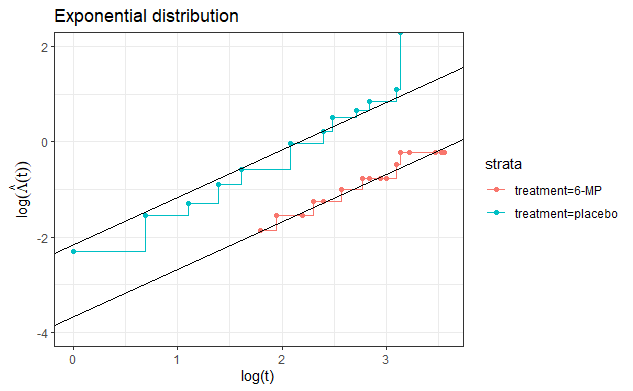

```r
aft_viz<-ggplot(km,aes(x=lt,y=lls, col= strata))+
  geom_point()+
  geom_step()+
  geom_abline(intercept = lam0,slope=1)+
  geom_abline(intercept = lam1,slope=1)+
  labs(x="log(t)",y=expression(log(hat(Lambda)(t))),title = "Exponential distribution")+
  ylim(c(-4,2))+
  theme_bw()
aft_viz
```

The assumptions are almost and thus the straight linear line is achieve.

#### Weibull

Accelertion Factor: a= exp(coef[1])

```r
weibull<- survreg(Surv(time,status)~ treatment,data=leuk2,
                  dist="weibull",score= TRUE)
summary(weibull)
```

```
Call:
survreg(formula = Surv(time, status) ~ treatment, data = leuk2,
    dist = "weibull", score = TRUE)
               Value Std. Error     z       p
(Intercept)    2.248      0.166 13.55 < 2e-16
treatment6-MP  1.267      0.311  4.08 4.5e-05
Log(scale)    -0.312      0.147 -2.12   0.034

Scale= 0.732

Weibull distribution
Loglik(model)= -106.6   Loglik(intercept only)= -116.4
    Chisq= 19.65 on 1 degrees of freedom, p= 9.3e-06
Number of Newton-Raphson Iterations: 5
n= 42
```

```r
print("Score/ Gradient value:")
```

```
[1] "Score/ Gradient value:"
```

```r
weibull$score
```

```
[1] -5.640003e-08 -3.161867e-09  5.083317e-08
```

Acceleration:

```r
exp(coef(weibull)[2])
```

```
treatment6-MP
     3.551374
```

Same as before with slope p=1/scale and log(-log(S(t))) = log(lambda) + p*log(t) with assumption 1. Intercept a= log(lambda)= P* -(coef[0]+ coef[1]* I), where I=0 for Placeba, 1 for treatment. 2. Slope p

```r
#slope:
p=1/weibull$scale
## intercept placebo group:
wlam0 <- p*(-coef(weibull)[1])
wlam0
```

```
(Intercept)
  -3.070704
```

```r
## intercept treatment group
wlam1 <- p*(-sum(coef(aft)))
wlam1
```

```
[1] -5.034316
```

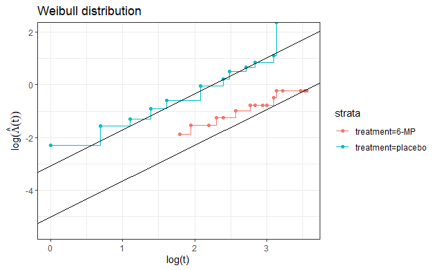

```r
wei_viz<-ggplot(km,aes(x=lt,y=lls, col= strata))+
  geom_point()+
  geom_step()+
  geom_abline(intercept = wlam0,slope=p)+
  geom_abline(intercept = wlam1,slope=p)+
  labs(x="log(t)",y=expression(log(hat(Lambda)(t))),title = "Weibull distribution")+
  ylim(c(-5.5,2))+
  theme_bw()
wei_viz
```

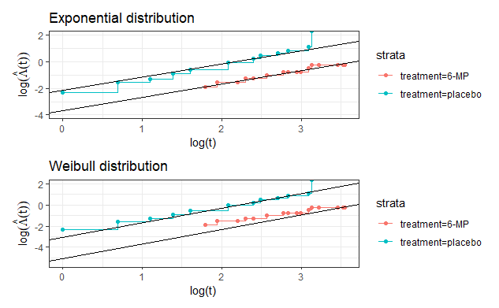

```r
library(patchwork)
aft_viz/wei_viz
```